# esATAC Report

Zheng Wei and Wei Zhang

2017-09-27

```r
load("Report.Rdata")
```

# 1 Summary Table

Sequence files below are set as inputs of the pipeline.

| Mate1.files | Mate2.files |
| --- | --- |
| /home/data/rawdata/bj5/atac-seq/G1/G1-lib-16-3-14-25k_L2_P503701.R1.adapter.fastq.gz | /home/data/rawdata/bj5/atac-seq/G1/G1-lib-16-3-14-25k_L2_P503701.R2.adapter.fastq.gz |
| /home/data/rawdata/bj5/atac-seq/G1/G1-lib-16-3-14-25k_L2_P503701.R1.clean.fastq.gz | /home/data/rawdata/bj5/atac-seq/G1/G1-lib-16-3-14-25k_L2_P503701.R2.clean.fastq.gz |
| /home/data/rawdata/bj5/atac-seq/G1/sd1G/G1-lib-16-3-14-25k_L1_Q603801.R1.adapter.fastq.gz | /home/data/rawdata/bj5/atac-seq/G1/sd1G/G1-lib-16-3-14-25k_L1_Q603801.R2.adapter.fastq.gz |
| /home/data/rawdata/bj5/atac-seq/G1/sd1G/G1-lib-16-3-14-25k_L1_Q603801.R1.clean.fastq.gz | /home/data/rawdata/bj5/atac-seq/G1/sd1G/G1-lib-16-3-14-25k_L1_Q603801.R2.clean.fastq.gz |

Summerized infomation on sequence files has been shown showed below. You can see details in later sections

[output not shown]

A nucleosome free region (NFR) must be present. A mononucleosome peak must be present in the fragment length distribution. These are reads that span a single nucleosome, so they are longer than 147 bp but shorter than 147*2 bp. Good ATAC-seq datasets have reads that span nucleosomes (which allows for calling nucleosome positions in addition to open regions of chromatin).

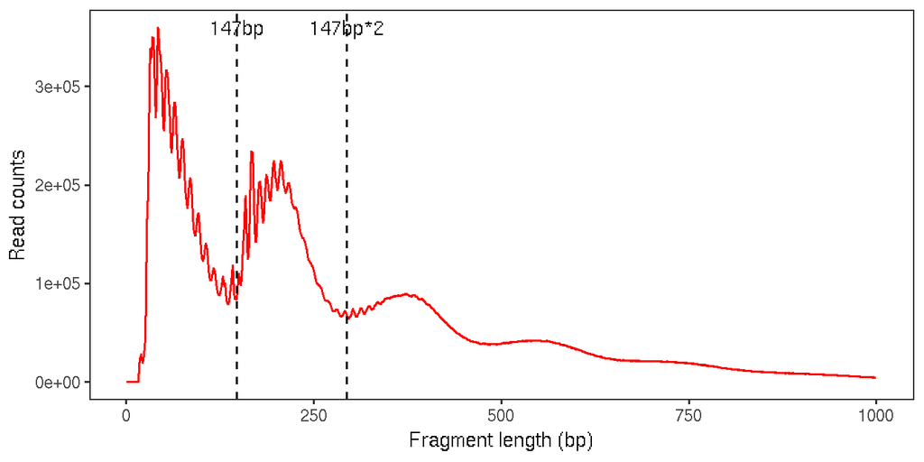

# 2 Sequence statistics

## 2.1 FastQC

Quality control for the sequence data

## 2.2 Remove Adapter

The adapter sequence are shown below. For paired end reads, if adapters were not setted, the adapters below are identified by AdapterRemoval.

| Item | Value |
| --- | --- |
| adapter1 | CTGTCTCTTATACACATCTCCGAGCCCACGAGACTAAGGCGAATCTCGTATGCCGTCTTCTGCTTGAAAAAAAAAAAAAAAAAAAAAAAAAAAAAAAAAAAAAAAAAAAAAAAA |
| adapter2 | CTGTCTCTTATACACATCTGACGCTGCCGACGAAGAGGATAGTGTAGATCTCGGTGGTCGCCGTATCATTAAAAAAAAAAAAAAAAAAAAAAAAAAAAAAAAAAAAAAAAAATA |

The statistic of adapter removing are show below.

| Item | Value |
| --- | --- |
| Total number of read pairs | 125083358 |
| Number of unaligned read pairs | 33231344 |
| Number of well aligned read pairs | 91852014 |
| Number of discarded mate 1 reads | 18197 |
| Number of singleton mate 1 reads | 0 |
| Number of discarded mate 2 reads | 18197 |
| Number of singleton mate 2 reads | 0 |
| Number of reads with adapters[1] | 95161336 |
| Number of retained reads | 250130322 |
| Number of retained nucleotides | 26361696302 |
| Average length of retained reads | 105.392 |

For detail, you can visit [Website of AdapterRemoval on Github](https://github.com/MikkelSchubert/adapterremoval).

# 3 Reads alignment statistics

## 3.1 Bowtie2 alignment log

```
## [1] "125065161 reads; of these:"
## [2] "  125065161 (100.00%) were paired; of these:"
## [3] "    1473493 (1.18%) aligned concordantly 0 times"
## [4] "    94010387 (75.17%) aligned concordantly exactly 1 time"
## [5] "    29581281 (23.65%) aligned concordantly >1 times"
## [6] "98.82% overall alignment rate"
```

## 3.2 Library complexity

[output not shown]

## 3.3 Filtering statistics

| Item | Value | Reference |
| --- | --- | --- |
| Original total reads | 125.1M (125083358) |  |
| Reads after adapter removing (ratio) | 125.1M (99.99%, 125065161 / 125083358) | >99% |
| Total mapped reads (ratio of original reads) | 123.6M (98.81%, 123591668 / 125083358) | >95% |
| – Non-mitochondrial reads (ratio) | 97.9M (79.21%, 97890905 / 123591668) | >70% |
| – – Unique mapped reads (ratio) | 87.9M (71.10%, 87870315 / 123591668) | >60% |
| – – – Duplicate removed reads (ratio final for use) | 68.7M (55.57%, 68675487 / 123591668) | >25M,>60% |

## 3.4 Fregment size distribution

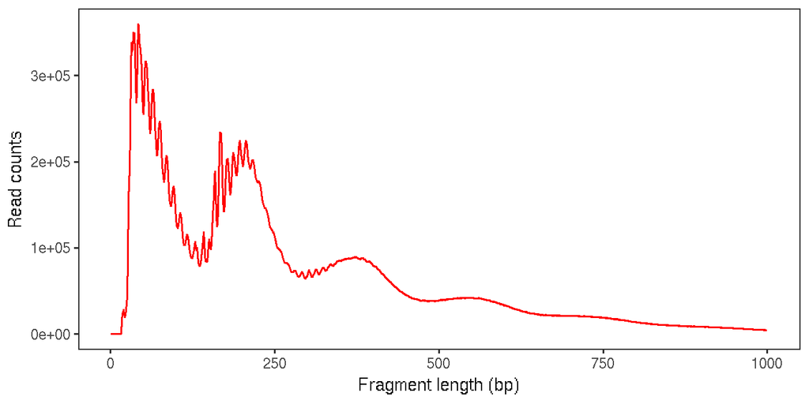

```r
library(ggplot2)
load("Report.Rdata")
readsCounts<-atacProcs$fregLenDistr$getReportVal("readsCounts")
ggplot(readsCounts[1:1000,], aes(length,counts))+geom_path(color="Red")+xlab("Fragment length (bp)")+ylab("Read counts") + theme_bw() + theme(panel.grid =element_blank())
```

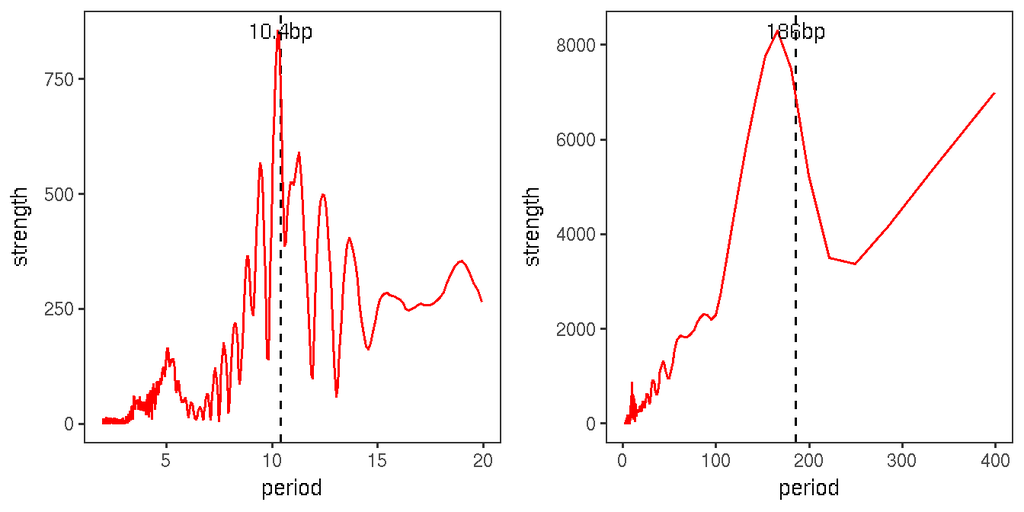

```r
library(stats)
strength<-Mod(fft(readsCounts$counts))/length(readsCounts$counts)
periodx<-length(readsCounts$counts)/(1:(length(readsCounts$counts)-1))
strength<-strength[2:length(strength)]

rs1<-as.data.frame(cbind(periodx[periodx<20&periodx>2],strength[periodx<20&periodx>2],0))
rs2<-as.data.frame(cbind(periodx[periodx<400&periodx>2],strength[periodx<400&periodx>2],1))
rs<-rbind(rs1,rs2)
colnames(rs)<-c("period","strength","check")

g1<-ggplot(rs[rs["check"]==0,]) + geom_vline(xintercept = 10.4, linetype=2)+ geom_line(aes(x=period,y=strength),color="Red")+ theme_bw() + theme(panel.grid =element_blank()) + annotate("text", x = 10.4, y = max(rs[rs["check"]==0,2]), label = "10.4bp") +xlab("period") + ylab("strength")

g2<-ggplot(rs[rs["check"]==1,]) + geom_vline(xintercept = 186, linetype=2)+ geom_line(aes(x=period,y=strength),color="Red")+ theme_bw() + theme(panel.grid =element_blank()) + annotate("text", x = 186, y = max(rs[rs["check"]==1,2]), label = "186bp") +xlab("period") + ylab("strength")
library(gridExtra)
grid.arrange(g1, g2, ncol=2)
```

## 3.5 TSS enrichment

The nucleosome free reads (<100bp) and monnucleosome span reads (180~247bp) enrichment around transcription starting site (TSS) are shown below.

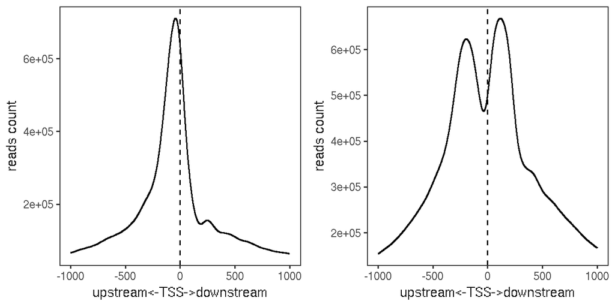

```r
library(ggplot2)
load("Report.Rdata")
df<-atacProcs$tssqc100$getReportVal("tss")
g1<-ggplot(df,aes(pos,counts))+geom_line()+ geom_vline(xintercept = 0, linetype=2)+xlab("upstream<-TSS->downstream")+ylab("reads count")+theme_bw() + theme(panel.grid =element_blank())
df<-atacProcs$tssqc180_247$getReportVal("tss")
g2<-ggplot(df,aes(pos,counts))+geom_line()+ geom_vline(xintercept = 0, linetype=2)+xlab("upstream<-TSS->downstream")+ylab("reads count")+theme_bw() + theme(panel.grid =element_blank())
grid.arrange(g1, g2, ncol=2)
```

# 4 Peak statistics

## 4.1 Blacklist ratio

| Item | Value |
| --- | --- |
| Total peaks | 235869 |
| Blacklist regions | 167 |
| Ratio | 0.00 |

## 4.2 DHS ratio

| Item | Value |
| --- | --- |
| Total peaks | 235869 |
| DHS regions | 218457 |
| Ratio | 0.93 |

## 4.3 Fraction of reads in peaks (FRiP)

| Item | Value |
| --- | --- |
| The number of reads in peak | 15173514 |
| The number of total reads | 18442688 |
| The number of total peaks | 235869 |
| FRiP | 0.82 |

## 4.4 Peak Annotation

[output not shown]

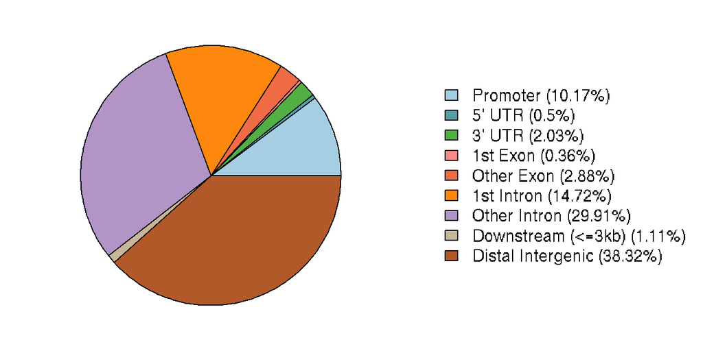

# 5 Go analysis

Gene ontology analysis for all genes around peak regions.

| ID | Description | GeneRatio | pvalue | qvalue |
| --- | --- | --- | --- | --- |
| GO:0007409 | axonogenesis | 417/15102 | 0.0000000 | 0.0000000 |
| GO:0061564 | axon development | 451/15102 | 0.0000000 | 0.0000000 |
| GO:0007507 | heart development | 488/15102 | 0.0000000 | 0.0000000 |
| GO:0022604 | regulation of cell morphogenesis | 416/15102 | 0.0000000 | 0.0000000 |
| GO:0048514 | blood vessel morphogenesis | 480/15102 | 0.0000000 | 0.0000000 |
| GO:0001501 | skeletal system development | 473/15102 | 0.0000000 | 0.0000000 |
| GO:0044708 | single-organism behavior | 397/15102 | 0.0000000 | 0.0000000 |
| GO:0198738 | cell-cell signaling by wnt | 458/15102 | 0.0000000 | 0.0000000 |
| GO:0016055 | Wnt signaling pathway | 457/15102 | 0.0000000 | 0.0000000 |
| GO:0051962 | positive regulation of nervous system development | 441/15102 | 0.0000000 | 0.0000000 |
| GO:1902532 | negative regulation of intracellular signal transduction | 455/15102 | 0.0000000 | 0.0000000 |
| GO:1901652 | response to peptide | 436/15102 | 0.0000000 | 0.0000000 |
| GO:0023061 | signal release | 404/15102 | 0.0000000 | 0.0000000 |
| GO:0045860 | positive regulation of protein kinase activity | 464/15102 | 0.0000000 | 0.0000000 |
| GO:0007389 | pattern specification process | 410/15102 | 0.0000000 | 0.0000000 |
| GO:0048511 | rhythmic process | 310/15102 | 0.0000000 | 0.0000000 |
| GO:0016049 | cell growth | 467/15102 | 0.0000000 | 0.0000000 |
| GO:0010975 | regulation of neuron projection development | 392/15102 | 0.0000000 | 0.0000000 |
| GO:0016311 | dephosphorylation | 407/15102 | 0.0000000 | 0.0000000 |
| GO:0042391 | regulation of membrane potential | 370/15102 | 0.0000000 | 0.0000000 |
| GO:0001503 | ossification | 364/15102 | 0.0000000 | 0.0000000 |
| GO:0048568 | embryonic organ development | 408/15102 | 0.0000000 | 0.0000000 |
| GO:0060271 | cilium assembly | 328/15102 | 0.0000000 | 0.0000000 |
| GO:0006644 | phospholipid metabolic process | 434/15102 | 0.0000000 | 0.0000000 |
| GO:0043434 | response to peptide hormone | 390/15102 | 0.0000000 | 0.0000000 |
| GO:0007009 | plasma membrane organization | 273/15102 | 0.0000000 | 0.0000001 |
| GO:0007264 | small GTPase mediated signal transduction | 473/15102 | 0.0000000 | 0.0000001 |
| GO:0071900 | regulation of protein serine/threonine kinase activity | 458/15102 | 0.0000000 | 0.0000001 |
| GO:0000226 | microtubule cytoskeleton organization | 429/15102 | 0.0000000 | 0.0000001 |
| GO:0001933 | negative regulation of protein phosphorylation | 385/15102 | 0.0000000 | 0.0000001 |

[output cut: 729 more lines]

# 6 Footprint analysis

The following figure is CTCF footprint.

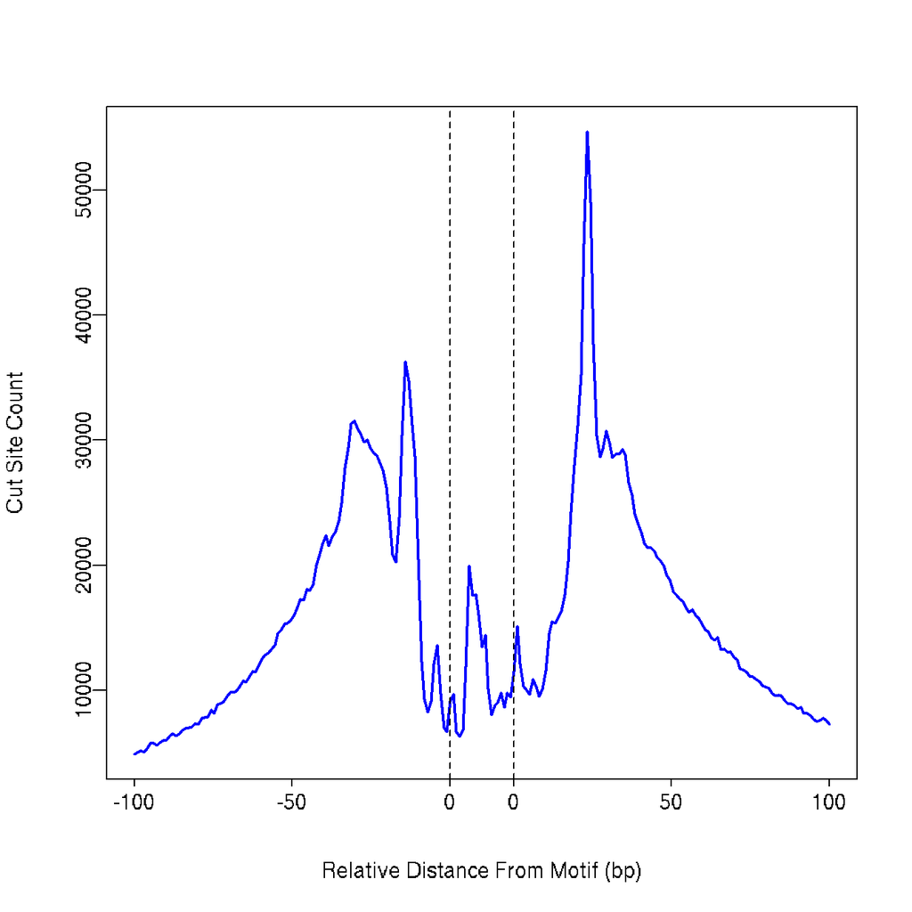

# 7 Annotation of items in table

For single end sequencing data, ATACFlow will counts reads number.

For paired end sequencing data, ATACFlow will counts read pairs or fragment number.

- **Sequence files type** is the type of sequencing data: single end data and paired end data. If paired end reads are stored in one file interleavedly rather than two files, “it is call”interleaved.
- **Original total reads** is the sample’s raw total reads (pairs) number.
- **Reads after adapter removing (ratio)** is the reads (pairs) number after adapter removing and the percentage of retained reads in original total reads. The larger value shows the better quality.
- **Total mapped reads (ratio)**  
  is the reads (pairs) number mapped to reference genome and the percentage of mapped reads in original total reads (alignment rate). ENCODE recommend that the alignment rate, or percentage of mapped reads, should be greater than 95%, though values >80% may be acceptable.
- **Unique locations mapped uniquely**  
  is the number of distinct uniquely mapping reads (i.e. after removing duplicates).
- **Non-Redundant Fraction (NRF)** is the value of: Unique locations mapped uniquely / Total mapped reads. ENCODE recommend NRF>0.9 for ATAC-seq data.

[output not shown]

- **Locations with only 1 reads mapping uniquely** is the number of genomic locations where exactly one read maps uniquely.
- **Locations with only 2 reads mapping uniquely** is the number of genomic locations where two reads map uniquely.
- **PCR Bottlenecking Coefficients 1 (PBC1)** is the value of: Locations with only 1 reads mapping uniquely / Unique locations mapped uniquely. ENCODE recommend that PBC1>0.9 for ATAC-seq data.

[output not shown]

- **PCR Bottlenecking Coefficients 2 (PBC2)** is the value of: Locations with only 1 reads mapping uniquely / Locations with only 2 reads mapping uniquely. ENCODE recommend that PBC2>3 for ATAC-seq data.

| $PBC2$ value range | Bottlenecking level |
| --- | --- |
| $PBC2<1$ | Severe |
| $1\le PBC2 \le 3$ | Moderate |
| $PBC2>3$ | None |